# Minion sequencing of sars-cov-2 using the ARTIC tiling method

Some libraries

```python
from IPython.display import Image

import pandas as pd
import numpy as np
import matplotlib.pyplot as plt
import seaborn as sns
```

### Extraction, RT, PCR, barcoding and adapter ligation

- Extraction was done using the KingFisher
  - Samples 24, 48, 72 and 96 or barcodes NB87, NB90, NB93 and NB96 were negative controls
    - (sorry for this confusion)
- RT and PCR was done using the: NEBNext ARTIC SARS-CoV-2 Companion Kit (Oxford Nanopore Technologies)
  - Chapter 1
- Barcoding pool cleanup using NEBnext beads
  - **3.5 ng/uL** was obtained of this **17 uL** was used in the adapter ligation reaction
- Cleanup of adapter ligation using NEBnext beads
  - **1.8 ng/uL** was obtained of which **11 uL** was used for the loading library for the Minion flow cell

### Minion prep

- Oxford Nanopore Protocol SQK-LSK109

### Plate layout of barcodes vs sample numbers

At the time I did not see the confusion of this

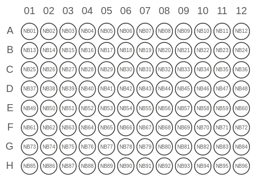

```python
Image("../BARCODES.png")
```

Sample names used for gels (and associated episode numbers) uses a numbering scheme where A01 = 1, H01 = 8, A02 = 9, H03 = 24 and so on.

NB87 (24), NB90 (48), NB93 (72) and NB96 (96) were the negative controls

### Gels

Due to lab schedules and limited kit components the following gel checks were used. The idea here was that if samples failed in on of the pools there is anyway nothing to be done in terms of repeating and one would be able to see this in the data. Also even samples that failed on the gel was sequenced for the same reason.

The bottom row for both pools was run separately to make sure neither had contamination in the negative controls.

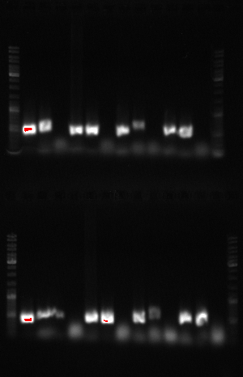

```python
Image("../Gels/bottom.png")
```

Sorry for the bad looking gels. Every 3rd sample is a negative control with top being pool 1 and bottom being pool 2. Only primer dimers are visible in the NCs. This was used as a sample to see if at least that both tiling PCRs worked before pooling. Not ideal, but there was not much time and if there was a problem not much to be done.

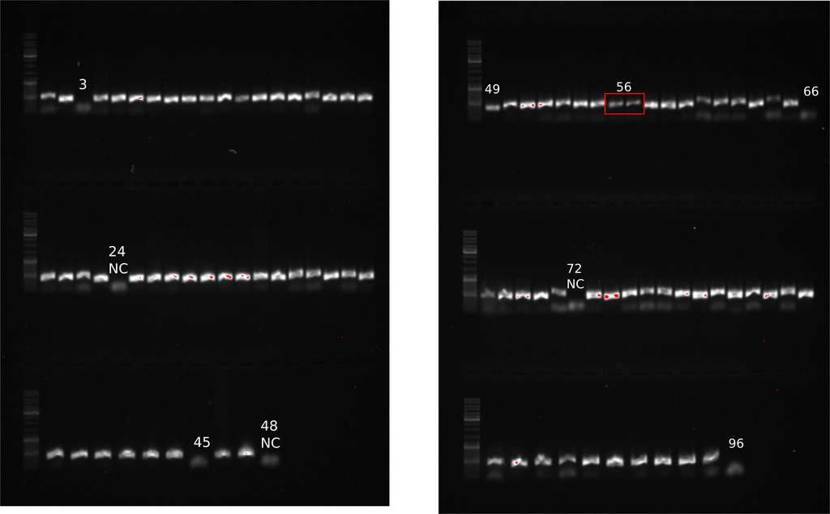

```python
Image("../Gels/T1 and T2 pooled.png")
```

The above gel picture shows the pooled amplicons. The NCs are annotated and looks as expected from the previous gel. The annotation uses sample number and not barcode numbers. The well were loaded 3 uL mixed into 2 uL loading dye and this was loaded using 2 pipette transfers into the wells, this way sample 56 was accidentally loaded in two separate wells.

Use a sample naming scheme to utilize the barcode names.

**ONPddmmyyNB01**

This will allow to keep *easy* track of positional info and places of negative controls. Batches will correspond to the date.

### Basecalling and barcoding

```python
%%bash
## From:
# https://artic.network/ncov-2019/ncov2019-bioinformatics-sop.html

## Install
# https://github.com/nanoporetech/vbz_compression

# copy the plugin to the conda environment, or it will complain

cp /usr/local/hdf5/lib/plugin/libvbz_hdf_plugin.so /home/armand/anaconda3/envs/artic-ncov2019/lib/hdf5/plugin/

guppy_basecaller -c ~/guppy/ont-guppy/data/dna_r9.4.1_450bps_sup.cfg -i 180821/ \
-s 180821_24H -x "cuda:0 cuda:1 cuda:2 cuda:3 cuda:4 cuda:5 cuda:6 cuda:7" -r

guppy_barcoder guppy_barcoder --require_barcodes_both_ends -i 180821_24H_called/ \
-s 180821_24H_demultiplexed --arrangements_files "barcode_arrs_nb96.cfg" -x "cuda:0" -r
```

### Using the analysis from the ARTIC group

```python
%%bash
# once
mkdir 1_normalReadFiles
mkdir 2_articResults

# loop 1 to 9
for n in {1..9}
do
    mkdir 2_articResults/ONP180821NB0$n
    artic guppyplex --min-length 400 --max-length 700 --directory  180821_24H_demultiplexed/barcode0$n \
    --prefix 1_normalReadFiles/ONP180821NB0$n


    artic minion --normalise 200 --threads 16 --scheme-directory artic-ncov2019/primer_schemes/ \
    --read-file 1_normalReadFiles/ONP180821NB0$n\_barcode0$n.fastq \
    --fast5-directory /storage/sdc/fast5/ \
    --sequencing-summary sequencing_summary.txt \
    nCoV-2019/V3 2_articResults/ONP180821NB0$n/ONP180821NB0$n
done

# loop 10 to 96
for n in {10..96}
do
    mkdir 2_articResults/ONP180821NB$n
    artic guppyplex --min-length 400 --max-length 700 --directory 180821_24H_demultiplexed/barcode$n \
    --prefix 1_normalReadFiles/ONP180821NB$n


    artic minion --normalise 200 --threads 16 --scheme-directory artic-ncov2019/primer_schemes/ \
    --read-file 1_normalReadFiles/ONP180821NB$n\_barcode$n.fastq \
    --fast5-directory /storage/sdc/fast5/ \
    --sequencing-summary sequencing_summary.txt \
    nCoV-2019/V3 2_articResults/ONP180821NB$n/ONP180821NB$n
done
```

### Results from nextclade

https://clades.nextstrain.org/

```python
nextDf = pd.read_csv('combined.csv', sep = ";")
keep = ['seqName', 'clade', 'qc.overallScore', 'qc.overallStatus','missing', 'totalMissing',
        'qc.privateMutations.status', 'qc.missingData.status','qc.mixedSites.status',
       'qc.snpClusters.status']
nextDf = nextDf[keep]
```

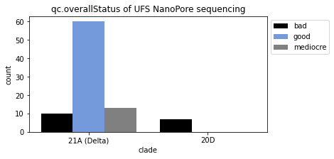

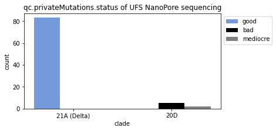

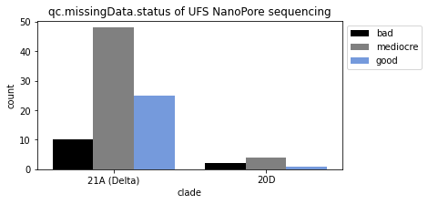

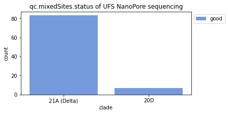

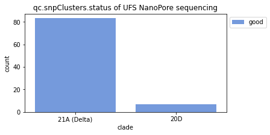

```python
for thing in ['qc.overallStatus',
              'qc.privateMutations.status',
              'qc.missingData.status',
              'qc.mixedSites.status',
              'qc.snpClusters.status']:
    plt.figure(figsize=(6,3))
    sns.countplot(data=nextDf, x='clade', hue=thing, dodge=True,
                 palette={'good': 'cornflowerblue',
                          'mediocre': 'gray',
                          'bad': 'black'})
    plt.legend(bbox_to_anchor=(1, 1), loc=2)
    plt.title(f"{thing} of UFS NanoPore sequencing");
```

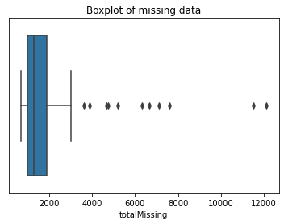

```python
sns.boxplot(x=nextDf['totalMissing'])
plt.title('Boxplot of missing data');
```

From the boxplot above we can see that most of the samples with missing bases are below 3000 (~10% of the genome). I know the the people doing the phylogeography uses samples below 10% missing.

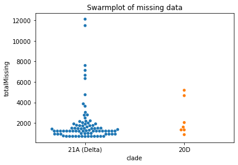

```python
sns.swarmplot(data=nextDf, x='clade', y='totalMissing')
plt.title('Swarmplot of missing data');
```

### Conclusion

Overall the results look good, but there is plenty room for improvement. Better preQC using gel electrophoresis. Surplus reagents to allow repeating failed samples or replacing samples. After investigation sample 3 had a single target ct with value of 36 - this should not have been stored. Real time analysis of coverage per barcode can indicate how to create new barcode pools with can then be ran on the same flow cell. Let say 24 samples are slow in gaining coverage these can be barcoded again with the same barcodes, pooled and preped for sequencing. This removes the cost of a new flow cell and the competition during adapter ligation and sequencing.

I have not looked into the the individual samples and there issues.